# Expansion: The Borg Brewery

James Jarding, Nikhil Gupta, Max Moro

September 29, 2018

[figure not shown]

GitHub Repository: [https://github.com/jth1911/SMU_MSDS_6306_CS1]

# Background

The BeerBorg.com is a Beer company that combines the love for Star Trek and beer. Who would have ever imagined someone would get tired of the typical draft beer and decide to brew our on own beer. It started out as a small group competition that resulted in picking a few brews, purchasing a building to meet and finally a full blown brewery that attracts not just Star Wars fans but fans of science fiction in general. The Borg has assimilated 10 different draft beers and 2 seasonal beers.

# Objective

Last month, the talk of selling the brew to other breweries caught fire, BeerBorgs approached Collective.ai to perform analysis about the market. Way too many ideas were thrown on the table and most were not based on any research. In an attempt to further the discussion, we (James, Max and Nikhil) decided to do some research hoping to channel the discussion around factual data to best of our knowledge. The data we have collected contains a sample of breweries by city/state and the desired taste by state, including correlations between ABV/IBU and between population and market size. This will help to narrow the focus to areas where beer is seen as a necessity and a strong opinion as to the desired taste.

# Breweries by State

First, lets take a look at the data we have. Keep in mind, this isn’t an exhaustive list of breweries but just a sample by state. If we had an exhaustive list of breweries just imagine the decisions we’ll be able to safely make.

```r
beers = read.csv('data/Beers.csv')
breweries = read.csv('data/Breweries.csv') %>%
  mutate(State = trimws(State,'both')) #removing trailing spaces

str(beers)
```

```
## 'data.frame':    2410 obs. of  7 variables:
##  $ Name      : Factor w/ 2305 levels "#001 Golden Amber Lager",..: 1638 577 1705 1842 1819 268 1160 758 1093 486 ...
##  $ Beer_ID   : int  1436 2265 2264 2263 2262 2261 2260 2259 2258 2131 ...
##  $ ABV       : num  0.05 0.066 0.071 0.09 0.075 0.077 0.045 0.065 0.055 0.086 ...
##  $ IBU       : int  NA NA NA NA NA NA NA NA NA NA ...
##  $ Brewery_id: int  409 178 178 178 178 178 178 178 178 178 ...
##  $ Style     : Factor w/ 100 levels "","Abbey Single Ale",..: 19 18 16 12 16 80 18 22 18 12 ...
##  $ Ounces    : num  12 12 12 12 12 12 12 12 12 12 ...
```

```r
str(breweries)
```

```
## 'data.frame':    558 obs. of  4 variables:
##  $ Brew_ID: int  1 2 3 4 5 6 7 8 9 10 ...
##  $ Name   : Factor w/ 551 levels "10 Barrel Brewing Company",..: 355 12 266 319 201 136 227 477 59 491 ...
##  $ City   : Factor w/ 384 levels "Abingdon","Abita Springs",..: 228 200 122 299 300 62 91 48 152 136 ...
##  $ State  : chr  "MN" "KY" "MA" "CA" ...
```

```r
# Both dataframes have column called 'Name'.
# In beers, it refers to the name of the beer
# In breweries, it refers to the name of the breweries.
# Let's rename for clarity, especially after merging.

names(beers)[names(beers) %in% 'Name'] <- 'Beer'
names(breweries)[names(breweries) %in% 'Name'] <- 'Brewery'

str(beers)
```

```
## 'data.frame':    2410 obs. of  7 variables:
##  $ Beer      : Factor w/ 2305 levels "#001 Golden Amber Lager",..: 1638 577 1705 1842 1819 268 1160 758 1093 486 ...
##  $ Beer_ID   : int  1436 2265 2264 2263 2262 2261 2260 2259 2258 2131 ...
##  $ ABV       : num  0.05 0.066 0.071 0.09 0.075 0.077 0.045 0.065 0.055 0.086 ...
##  $ IBU       : int  NA NA NA NA NA NA NA NA NA NA ...
##  $ Brewery_id: int  409 178 178 178 178 178 178 178 178 178 ...
##  $ Style     : Factor w/ 100 levels "","Abbey Single Ale",..: 19 18 16 12 16 80 18 22 18 12 ...
##  $ Ounces    : num  12 12 12 12 12 12 12 12 12 12 ...
```

```r
str(breweries)
```

```
## 'data.frame':    558 obs. of  4 variables:
##  $ Brew_ID: int  1 2 3 4 5 6 7 8 9 10 ...
##  $ Brewery: Factor w/ 551 levels "10 Barrel Brewing Company",..: 355 12 266 319 201 136 227 477 59 491 ...
##  $ City   : Factor w/ 384 levels "Abingdon","Abita Springs",..: 228 200 122 299 300 62 91 48 152 136 ...
##  $ State  : chr  "MN" "KY" "MA" "CA" ...
```

## How many breweries are present in each state?

Counting the number of breweries per each State

```r
breweriesState = breweries %>% count(State) # Option 2 . This is better!
DT::datatable(breweriesState,rownames = F)
```

| State | n |
| --- | --- |
| AK | 7 |
| AL | 3 |
| AR | 2 |
| AZ | 11 |
| CA | 39 |
| CO | 47 |
| CT | 8 |
| DC | 1 |
| DE | 2 |
| FL | 15 |

[output cut: 41 more lines]

With a more extensive data set we can begin to answer the following questions:

Where can we focus our research?

- Top 10 States: CO, CA, MI, OR, TX, PA, MA, WA, IN, WI

Where should we avoid making strong assumptions (Note that this is an observational study and could be affected by confounding variables such as population density, urban vs. rural locations, etc.)?

- Bottom 10 States: DC, ND, SD, WV, AR, DE, MS, NV, AL, KS

## Map of States and Breweries

A visual chart of number of breweries by State can help to identify geographical patterns.

```r
#adding the count columns to the states spatial data
states = sp::merge(states,breweriesState,by.x='abb',by.y='State')

bins <- c(0, 5, 10, 15, 20, 30,Inf)
pal <- colorBin("YlOrRd", domain = states$n, bins = bins)

labels <- sprintf("<strong>%s</strong><br/>%g Breweries",states$name, states$n) %>% lapply(htmltools::HTML)

leaflet(states) %>%
  setView(-96, 37.8, 4) %>%
  addProviderTiles("MapBox", options = providerTileOptions(
    id = "mapbox.light",
    accessToken = Sys.getenv('MAPBOX_ACCESS_TOKEN'))) %>%
  addPolygons(
    fillColor = ~pal(n),
    weight = 2,
    opacity = 1,
    color = "white",
    dashArray = "3",
    fillOpacity = 0.7,
    highlight = highlightOptions(
      weight = 5,
      color = "#666",
      dashArray = "",
      fillOpacity = 0.7,
      bringToFront = TRUE),
    label = labels,
    labelOptions = labelOptions(
      style = list("font-weight" = "normal", padding = "3px 8px"),
      textsize = "15px",
      direction = "auto")) %>%
  addLegend(pal = pal, values = ~n, opacity = 0.7,
            position = "bottomright", title='Breweries per State')
```

[interactive chart not shown]

A more visual representation shows the top 3 states:

- Colorado - 47 breweries
- California - 39 breweries
- Michigan - 32 breweries

If we’re going to expand we should start our in depth research with these three states but first let’s take a look at the types of beer that are popular in the these states.

# Merge beer w/breweries

Merge beer data with the breweries data. Print the first 6 observations and the last six observations to check the merged file

```r
data = merge(beers,breweries,by.x='Brewery_id',by.y='Brew_ID',all=T)

h4('First 6 Observations')
```

#### First 6 Observations

```r
DT::datatable(head(data,6),rownames = F)
```

| Brewery_id | Beer | Beer_ID | ABV | IBU | Style | Ounces | Brewery | City | State |
| --- | --- | --- | --- | --- | --- | --- | --- | --- | --- |
| 1 | Get Together | 2692 | 0.045 | 50 | American IPA | 16 | NorthGate Brewing | Minneapolis | MN |
| 1 | Maggie's Leap | 2691 | 0.049 | 26 | Milk / Sweet Stout | 16 | NorthGate Brewing | Minneapolis | MN |
| 1 | Wall's End | 2690 | 0.048 | 19 | English Brown Ale | 16 | NorthGate Brewing | Minneapolis | MN |
| 1 | Pumpion | 2689 | 0.06 | 38 | Pumpkin Ale | 16 | NorthGate Brewing | Minneapolis | MN |
| 1 | Stronghold | 2688 | 0.06 | 25 | American Porter | 16 | NorthGate Brewing | Minneapolis | MN |
| 1 | Parapet ESB | 2687 | 0.056 | 47 | Extra Special / Strong Bitter (ESB) | 16 | NorthGate Brewing | Minneapolis | MN |

```r
h4('Last 6 Observations')
```

#### Last 6 Observations

```r
DT::datatable(tail(data,6),rownames = F)
```

| Brewery_id | Beer | Beer_ID | ABV | IBU | Style | Ounces | Brewery | City | State |
| --- | --- | --- | --- | --- | --- | --- | --- | --- | --- |
| 556 | Pilsner Ukiah | 98 | 0.055 |  | German Pilsener | 12 | Ukiah Brewing Company | Ukiah | CA |
| 557 | Heinnieweisse Weissebier | 52 | 0.049 |  | Hefeweizen | 12 | Butternuts Beer and Ale | Garrattsville | NY |
| 557 | Snapperhead IPA | 51 | 0.068 |  | American IPA | 12 | Butternuts Beer and Ale | Garrattsville | NY |
| 557 | Moo Thunder Stout | 50 | 0.049 |  | Milk / Sweet Stout | 12 | Butternuts Beer and Ale | Garrattsville | NY |
| 557 | Porkslap Pale Ale | 49 | 0.043 |  | American Pale Ale (APA) | 12 | Butternuts Beer and Ale | Garrattsville | NY |
| 558 | Urban Wilderness Pale Ale | 30 | 0.049 |  | English Pale Ale | 12 | Sleeping Lady Brewing Company | Anchorage | AK |

# Data Cleanliness Check

Some of the data is incomplete. A report of the number of NA’s in each column should give us the severity.

```r
countNA = sapply(data,function(x){sum(is.na(x))})
kable(countNA,col.names='Count of NA')
```

|  | Count of NA |
| --- | --- |
| Brewery_id | 0 |
| Beer | 0 |
| Beer_ID | 0 |
| ABV | 62 |
| IBU | 1005 |
| Style | 0 |
| Ounces | 0 |
| Brewery | 0 |
| City | 0 |
| State | 0 |

With any data that we obtain, we’ll need to verify it’s completeness and take the proper corrective action to ensure we are not making decisions based on an inaccurate data set.

# Alcohol Content and Bitterness

Compute the median alcohol content and international bitterness unit for each state. Plot a bar chart to compare

```r
summary = data %>%
  group_by(State) %>%
  summarise(ABVMedian = median(ABV,na.rm=T)
            ,IBUMedian = median(IBU,na.rm=T)
            )  %>%
  ungroup()

summary(summary)
```

```
##     State             ABVMedian         IBUMedian
##  Length:51          Min.   :0.04000   Min.   :19.00
##  Class :character   1st Qu.:0.05500   1st Qu.:30.00
##  Mode  :character   Median :0.05600   Median :35.00
##                     Mean   :0.05585   Mean   :36.98
##                     3rd Qu.:0.05800   3rd Qu.:42.75
##                     Max.   :0.06250   Max.   :61.00
##                                       NA's   :1
```

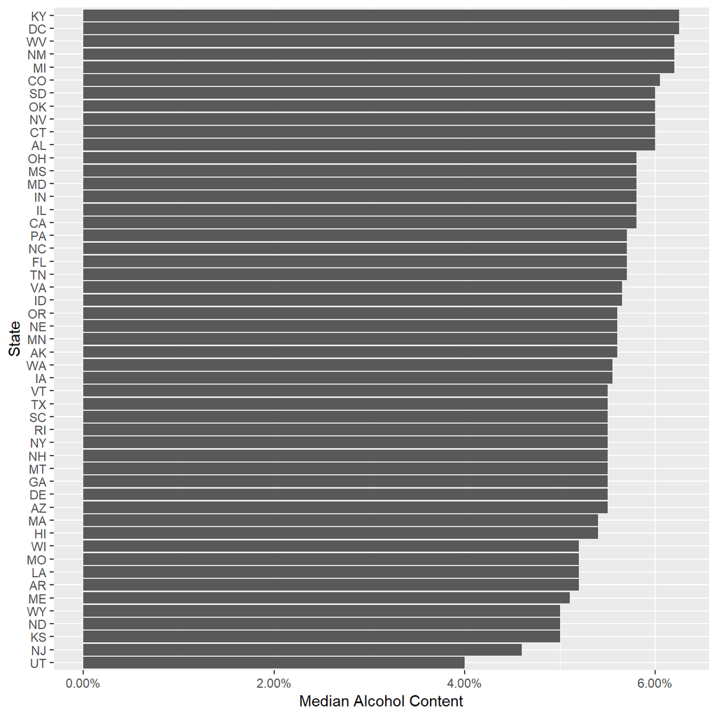

```r
ggplot(data=filter(summary,!is.na(ABVMedian))
       ,aes(x=fct_reorder(State,ABVMedian,desc=T)
                        ,y=ABVMedian)) +
  geom_col() +
  xlab("State") +
  ylab("Median Alcohol Content") +
  scale_y_continuous(labels=percent)+
  coord_flip()
```

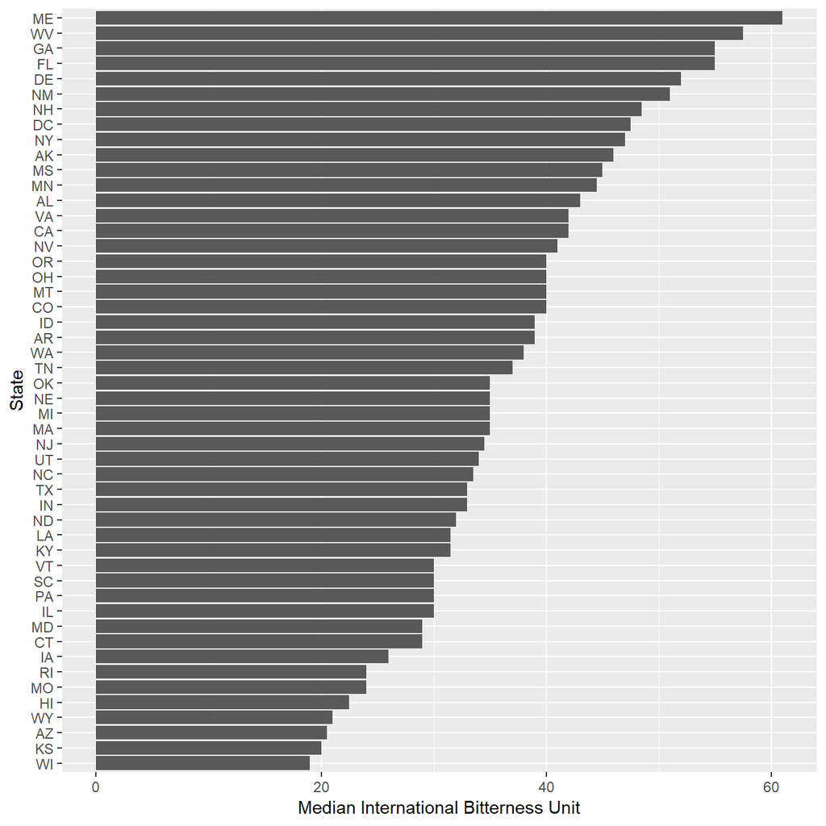

```r
ggplot(data=filter(summary,!is.na(IBUMedian))
       ,aes(x=fct_reorder(State,IBUMedian,desc=T)
                        ,y=IBUMedian)) +
  geom_col() +
  xlab("State") +
  ylab("Median International Bitterness Unit") +
  coord_flip()
```

# Max Alcohol Content and Bitterness

Which state has the maximum alcoholic (ABV) beer? Which state has the most bitter (IBU) beer?

```r
message("The State with the maximum alcoholic (ABV) beer is:"
        ,arrange(data,desc(ABV))$State[1]
        )
```

```
## The State with the maximum alcoholic (ABV) beer is:CO
```

```r
message("The State with the most bitter (IBU) beer is:"
        ,arrange(data,desc(IBU))$State[1]
        )
```

```
## The State with the most bitter (IBU) beer is:OR
```

## Map of States and their max ABV

A visual chart of Max ABV by State can help to identify geographical patterns.

Preparing the data

```r
#calculating max abv and mav ibu
statesABV_IBU=data %>%
  group_by(abb=State) %>%
  summarise(MaxABV= max(ABV,na.rm=T)
            ,MaxIBU = max(IBU,na.rm=T))  %>%
  ungroup()
#adding to the states map data frame
states = sp::merge(states,statesABV_IBU,by='abb',all.x=T)
```

Plotting the Map

```r
bins <- c(0.05, 0.07, 0.09, 0.10,Inf)
pal <- colorBin("YlOrRd", domain = states$MaxABV, bins = bins)

labels <- sprintf("<strong>%s</strong><br/>%g Max ABV",states$name, states$MaxABV) %>% lapply(htmltools::HTML)

leaflet(states) %>%
  setView(-96, 37.8, 4) %>%
  addProviderTiles("MapBox", options = providerTileOptions(
    id = "mapbox.light",
    accessToken = Sys.getenv('MAPBOX_ACCESS_TOKEN'))) %>%
  addPolygons(
    fillColor = ~pal(MaxABV),
    weight = 2,
    opacity = 1,
    color = "white",
    dashArray = "3",
    fillOpacity = 0.7,
    highlight = highlightOptions(
      weight = 5,
      color = "#666",
      dashArray = "",
      fillOpacity = 0.7,
      bringToFront = TRUE),
    label = labels,
    labelOptions = labelOptions(
      style = list("font-weight" = "normal", padding = "3px 8px"),
      textsize = "15px",
      direction = "auto")) %>%
  addLegend(pal = pal, values = ~MaxABV, opacity = 0.7,
            position = "bottomright", title='Max ABV per State')
```

[interactive chart not shown]

States with highest ABV are Colorado, Kentucky, Indiana, New York; all with an ABV value at or above 0.100

With the exception of Colorado, these states are located on the East of the country

## Map of States and their max IBU

A visual chart of Max IBU by State can help to identify geographical patterns.

```r
bins <- c(30,80,100,120,Inf)
pal <- colorBin("YlOrRd", domain = states$MaxIBU, bins = bins)

labels <- sprintf("<strong>%s</strong><br/>%g Max IBU",states$name, states$MaxIBU) %>% lapply(htmltools::HTML)

leaflet(states) %>%
  setView(-96, 37.8, 4) %>%
  addProviderTiles("MapBox", options = providerTileOptions(
    id = "mapbox.light",
    accessToken = Sys.getenv('MAPBOX_ACCESS_TOKEN'))) %>%
  addPolygons(
    fillColor = ~pal(MaxIBU),
    weight = 2,
    opacity = 1,
    color = "white",
    dashArray = "3",
    fillOpacity = 0.7,
    highlight = highlightOptions(
      weight = 5,
      color = "#666",
      dashArray = "",
      fillOpacity = 0.7,
      bringToFront = TRUE),
    label = labels,
    labelOptions = labelOptions(
      style = list("font-weight" = "normal", padding = "3px 8px"),
      textsize = "15px",
      direction = "auto")) %>%
  addLegend(pal = pal, values = ~MaxIBU, opacity = 0.7,
            position = "bottomright", title='Max IBU per State')
```

[interactive chart not shown]

States with Maximum IBU are: Oregon, Virginia, Massachusetts, Ohio, Minnesota, Vermont; all with an IBU value at or above 120.

With the exception of Oregon, these states are located on the East of the country

# Summarize ABV Variable

Summary statistics for the ABV variable:

```r
summary(data$ABV)
```

```
##    Min. 1st Qu.  Median    Mean 3rd Qu.    Max.    NA's
## 0.00100 0.05000 0.05600 0.05977 0.06700 0.12800      62
```

# ABV / Bitterness Relationship

Is there an apparent relationship between the bitterness of the beer and its alcoholic content? Draw a scatter plot.

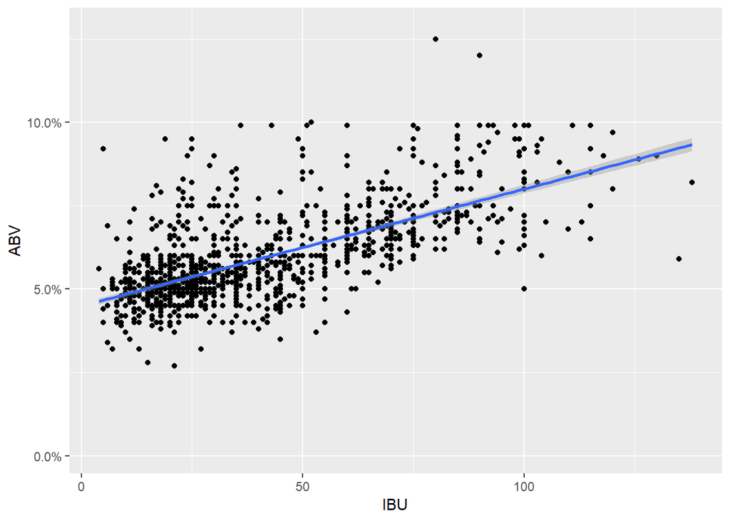

```r
ggplot(data=data,aes(x=IBU,y=ABV))+
  geom_point() +
  geom_smooth(method='lm') +
  scale_y_continuous(labels=percent)
```

```r
model=lm(data=data,formula=ABV~IBU)

corr=cor(data$ABV,data$IBU,method = 'pearson',use='complete.obs')
```

We have a correlation of 0.67 between IBV and IBU

We have a very slight positive slope between ABV and IBU, with a coefficient of 0.0351 of increase % Alcohol per IBU point

# Correlation with Population

The above data could be a little misleading since larger states may have more breweries. Should we set our strategy based on the population of each State? Is the Market driven by number of potential customers?

## Breweries and Population

Is there a correlation between Population and Number of Breweries in each State? Is so which State has opportunity to have more breweries based on its population?

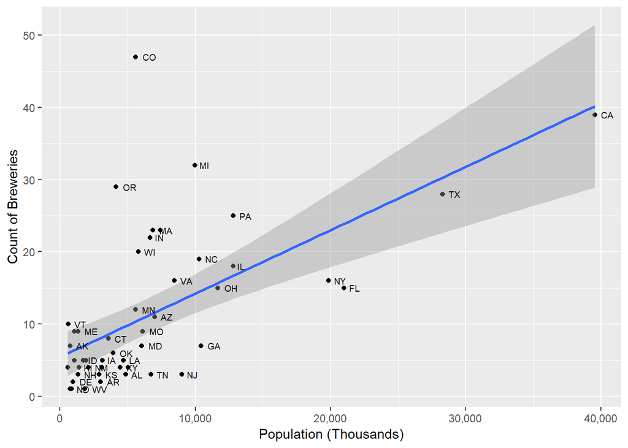

```r
#merge Beer, Breweries and populations
dataPop = data %>%
  left_join(select(dfStates,abb,pop),by=c("State"="abb"))

PopBrewery = dataPop %>%
  group_by(State,pop) %>%
  summarise(count = n_distinct(Brewery_id)) %>%
  ungroup()

ggplot(data=PopBrewery, aes(x=pop, y=count)) +
  geom_point() +
  geom_smooth(method='lm') +
  geom_text(aes(label=State),check_overlap=T,size=2.5,hjust=-.5) +
  scale_x_continuous(name='Population (Thousands)',labels=function(x){comma(x,scale=1/1000)}) +
  ylab("Count of Breweries")
```

```r
model=lm(data=PopBrewery,formula=pop~count)

corr=cor(PopBrewery$pop,PopBrewery$count,method = 'pearson',use='complete.obs')
```

We have a correlation of 0.61 between Population and number of Breweries in each State

We have a positive correlation between Population and number of Breweries in each State, with a coefficient of 420,090 people per each new Brewery

States below the trend line have the highest opportunity for Market Expansion